# Git / GitHub Intro

## Why?

- Sort of like change tracking in Word or Google Docs
- Collaborate without silently erasing someone else's work
- Edit your own work while keeping the option to undo those edits

## Why?

- The difference:
  - Code can break!
  - One project may involve many files
- We need a way to take "snapshots" of our code at a given point in time
- When we make modifications to working code, we want to be able to revert back to the working version if things go south
  - We also want to make sure that anyone who is using our code can still access the working version while we are making our updates

## Git and GitHub

- Git
  - Version control software
  - Installed locally on your computer
  - Tracks changes to files in your project directory (aka repository)
  - Lets you create multiple "branches"
    - Master branch contains the most up-to-date working version of the project
    - Use other branches to develop new functionality
      - Merge changes back into master branch when you're sure they work

## Git and GitHub

- GitHub
  - Website that hosts Git repositories
  - Great for collaboration

## Git Workflow

- Start a new project
  - Initialize a local Git repository
    - `git init`
  - Add project files to the staging area
    - `git add [filename]`
    - Can create files before or after initializing repo
  - Commit initial project files
    - `git commit -m "Initial project files"`

## Git Workflow

- Work on a project
  - Create a new branch
    - `git branch [branch name]`
    - `git checkout [branch name]`
  - Work on project, stage changes, commit changes, repeat
    - `git add [filename]`
    - `git commit -m "[descriptive message]"`
  - When the code works, merge with master branch
    - `git checkout master; git merge [branch name]`
  - Repeat!

## Git Basics

### Open Git Command Line

- Right click on project folder and select "Git Bash Here"

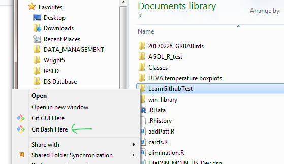

## Git Basics

### Initialize A Repository

- `git init`
- Tells Git to generate all the files it will need in order to keep track of your project folder and its contents

## Git Basics

### Check Status

- `git status`
- What branch am I on? What is the status of the files in my repository?

## Git Basics

### Add Files To The Staging Area

- `git add [filename]`
  - stages a specific file
- `git add *.R`
  - stages all R files in the project folder
- `git add *`
  - stages all files in the project folder
- Tells Git to include changes to these files in the next commit

## Git Basics

### Create a New Branch

- `git branch`
  - List current branches
- `git branch [branch name]`
  - Create new branch
- `git checkout [branch name]`
  - Switch to new branch

## Git Basics

### Commit changes

- `git commit -m "[descriptive message]"`
- Record a snapshot of staged files

## Git Basics

### Merge Branches

- `git checkout master`
  - Switch to master branch
- `git merge [branch name]`
  - Merge everything from a specific branch into the master branch
- `git branch -d [branch name]`
  - Delete old branches when you're done with them

## Git Basics

### View Version History and Revert to Older Version

- `git log`
  - View commit history for current branch
- `git checkout [commit]`
  - Set the working directory to its state at `[commit]`
  - When you checkout a commit, you are no longer on a branch, so commits you make from here will not be saved!

## Git Basics

### Undo a Commit

- `git revert [commit]`
  - Create a new commit that undoes the specified commit

## GitHub Workflow

- Start a new project
  - Create remote repository on GitHub
  - Initialize local repository, make an initial commit
  - Set the GitHub repository as the remote repository where the local repository will be pushed
  - Push changes in the local repository to GitHub

## GitHub Workflow

- Work on a project
  - Incorporate changes made by others into your local repository
  - Work in your local repository as usual
  - Push your work to GitHub

## GitHub Basics

### Create a GitHub Repository

[figure not shown]

## GitHub Basics

### Set a GitHub Repository as the Default Remote Repository

- `git remote add origin [GitHub repository URL]`
  - Set the GitHub repository as the remote repository where the local repository will be pushed

## GitHub Basics

### Push Local Changes to GitHub Repository

- `git push origin [branch name]`
  - Push changes in a specific branch to GitHub

## GitHub Basics

### Sync Local Repository with GitHub Repository

- `git checkout master; git pull`
  - Checkout the local master branch, fetch the master branch from GitHub, and merge it into the current local branch
  - This brings the local master branch up to date with the master branch on GitHub
- `git checkout [feature branch]; git merge master`
  - Merge the local master branch (now up to date with the remote master branch) into the local branch you are working in
  - Now the branch you are working in is up to date with the local and remote master branches

## Rules of Thumb

- One repository per project
  - Good: MOJN_IU_CalibrationAnalysis
  - Bad: MOJN_R_Code
- Commit early and often
- Use descriptive commit messages
  - Your collaborators and future self will thank you!

## References

https://jahya.net/blog/git-vs-github/

https://git-scm.com/

https://services.github.com/on-demand/downloads/github-git-cheat-sheet.pdf